# Medidas de tendencia central

Estadística 2022-2, [Facultad de economía](http://www.economia.unam.mx/)

2/3/2022

### 1. ¿Qué son las medidas de tendencia central? 🤔

Para este ejemplo, primero generaremos una serie de **100** números aleatorios entre **1** y **20** mediante la función `sample`. El argumento `TRUE` nos permitirá generar una muestra con remplazo:

```r
numeros <- sample(1:20, 100, TRUE)
numeros
```

```
##   [1]  8 11 14  4 13  8 19 12 12 18 14 18 13 10  6  3  9 10 18 17  8 19 14 20 16
##  [26] 13 19  1 14 15 12 10  9  1 19 10 14  6 17 18 11  6 15 12 11  1 17 13 12 18
##  [51]  7  4 16  7  4  1 19  8 20  9  1 17  9 19 10 17 20  2 14  8  8 16  8 16  2
##  [76] 11  1 10 15  1 13 17 13  5  5 12  9 10 12  4  6 16 20 17 20  9  3  8 16  4
```

### 2. Mediana 📍

Para obtener la **mediana**, podemos ordenar los `numeros` de menor a mayor, **el número que esté en medio de la muestra será la mediana**. Si utilizamos R, se puede hacer el cálculo de la **mediana** con la función `median`:

```r
mediana <- median(numeros)
mediana
```

```
## [1] 12
```

### 3. Media 🧮

$$Media ={\frac {1}{n}}\sum _{i=1}^{n}a_{i}={\frac {a_{1}+a_{2}+\cdots +a_{n}}{n}}$$

Si usamos R, podemos obtener la media de una muestra si utlilizamos la función **mean**:

```r
media <- mean(numeros)
media
```

```
## [1] 11.27
```

### 4. Moda 📊

Podemos saber cuál es la **frecuencia** (número de veces que aparece un elemento en una muestra) de cada número si dibujamos un **histograma** con la función `hist`, **aquel elemento con mayor frecuencia será la moda**:

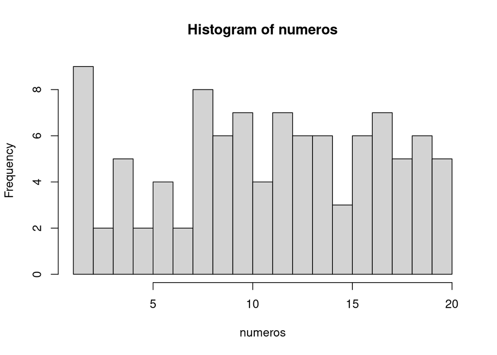

```r
# El argumento breaks nos permite dividir en histograma en las partes que queramos
hist(numeros, breaks = 20)
```

Para obtener un resultado con más precisión, podemos obtener la **moda** si generamos una **tabla de frecuencias** con la función `table` y la función `data.frame`, **aquel elemento con mayor frecuencia será la moda**:

```r
tabla.frecuencias <- data.frame(table(numeros))
tabla.frecuencias
```

```
##    numeros Freq
## 1        1    7
## 2        2    2
## 3        3    2
## 4        4    5
## 5        5    2
## 6        6    4
## 7        7    2
## 8        8    8
## 9        9    6
## 10      10    7
## 11      11    4
## 12      12    7
## 13      13    6
## 14      14    6
## 15      15    3
## 16      16    6
## 17      17    7
## 18      18    5
## 19      19    6
## 20      20    5
```

### 5. Ejercicio 👩‍💻👨‍💻✍

Aplica lo que aprendiste, obten la **mediana**, **media** y **moda** de la siguiente muestra de números:

```r
# Con la función seq, creamos una secuencia de 1 a 10 en intervalos de 0.1 en 0.1
secuencia <- seq(1, 10, 0.1)
muestra <- sample(secuencia, 100, TRUE)
muestra
```

```
##   [1]  6.3  1.6  9.2  1.4  1.5  7.1  4.2  9.1  5.8  3.3  1.9  3.0  5.8  1.0  6.1
##  [16]  2.5  5.3  7.4  7.6  1.3  8.1  7.1  1.5  5.4  1.6  2.5  3.0  3.9  3.7  1.8
##  [31]  7.5  6.5  9.9  8.7  3.5  2.1  1.3  8.1  2.2 10.0  9.9  2.8  7.3  8.1  3.6
##  [46]  7.8  6.8  2.9  4.4  1.8  2.7  5.9  8.9  7.4  4.3  8.1  1.0  8.8  3.2  2.6
##  [61]  9.9  4.7  6.4  2.9 10.0  5.7  2.4  2.1  7.2  6.1  9.7  8.0  4.2  9.3  6.4
##  [76]  8.0  7.2  3.6  8.7  4.1  2.0  4.1  3.7  2.8  2.9  1.7  3.1  1.3  1.4  7.0
##  [91]  8.9  4.2  5.9  6.8  8.0  7.5  2.5  8.3  1.6  4.5
```

##### Mediana

```r
# Aquí el cálculo de la mediana
```

##### Media

```r
# Aquí el cálculo de la media
```

##### Moda

```r
# Aquí el cálculo de la moda
```

💻[Código disponible en RStudio Cloud](https://rstudio.cloud/project/3671022)💻